# US_Accidents_Prediction

Team: Bhoomika Nanjaraja, Khush Shah, Apoorva Reddy Bagepalli, Devarsh Apurva Sheth

# Introduction

In response to the pressing issue of road safety in the United States, the project “Navigating Road Safety: Insights & Predictions on US Accidents (2016-2023)” has evolved its focus from predicting the severity of accidents to a novel proposal centered on forecasting potential locations for the introduction of new amenities. Acknowledging the staggering annual occurrence of over 6 million passenger car accidents, the project adopts a comprehensive approach, dissecting the intricate interplay of environmental and man-made factors contributing to these incidents. By analyzing years of data, the study aims to decode patterns and predictors that go beyond quantifying incidents, emphasizing the imperative of understanding multifaceted causes. The proposed features include city, street, severity proportion, existing amenities, response time, and a calculated weight based on severity proportion multiplied by response time added to the amenity factor. This innovative model aspires not only to identify potential locations for new amenities but also to pioneer strategies for mitigating risks and enhancing passenger safety, thereby catalyzing transformative changes in road safety measures and reducing casualties. The overarching objective is a testament to the belief that preventing accidents is a significant stride towards preserving human life and improving the quality of road travel for all.

# Data Description

# SMART Questions

1. Is there a notable contrast in the severity of accidents across various cities and streets?
2. How does the response time differ among different cities?
3. In terms of amenities, how does the comparison between existing and new amenities vary across cities?

# Exploratory Data Analysis

Reading the US Accidents Related data from CSV File.

```r
df = read.csv('US_Accidents.csv')
head(df, 5)
```

```
##      City                   Street SeverityProportion Amenity Response.time
## 1 Atlanta               10th St NW          3.041e-06       0            12
## 2 Atlanta          Abernathy Rd NE          4.090e-07       0            12
## 3 Atlanta          Abernathy Rd NW          2.340e-07       0            12
## 4 Atlanta  Atlanta Silverbacks Way          8.770e-07       0            12
## 5 Atlanta             Atwood St SW          3.510e-07       0            12
##      Weights New.Amenity
## 1 3.6492e-05           1
## 2 4.9080e-06           0
## 3 2.8080e-06           0
## 4 1.0524e-05           1
## 5 4.2120e-06           0
```

```r
str(df)
```

```
## 'data.frame':    13034 obs. of  7 variables:
##  $ City              : chr  "Atlanta" "Atlanta" "Atlanta" "Atlanta" ...
##  $ Street            : chr  " 10th St NW" " Abernathy Rd NE" " Abernathy Rd NW" " Atlanta Silverbacks Way" ...
##  $ SeverityProportion: num  3.04e-06 4.09e-07 2.34e-07 8.77e-07 3.51e-07 ...
##  $ Amenity           : int  0 0 0 0 0 0 0 0 0 0 ...
##  $ Response.time     : num  12 12 12 12 12 12 12 12 12 12 ...
##  $ Weights           : num  3.65e-05 4.91e-06 2.81e-06 1.05e-05 4.21e-06 ...
##  $ New.Amenity       : int  1 0 0 1 0 0 0 0 0 0 ...
```

```r
sum(is.na(df))
```

```
## [1] 0
```

Boxplot of distribution of the Weighted value of Severity Proportion, Response Time and Old Amentiy

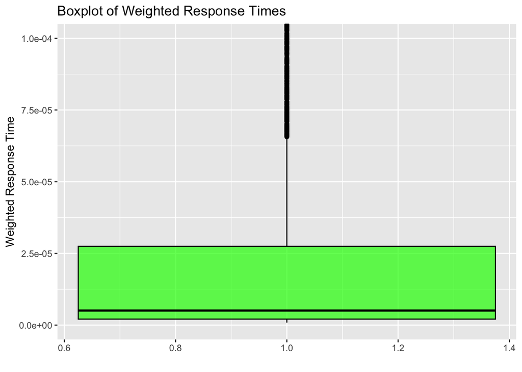

```r
df$Weighted_Response_Time <- df$Weights

# Alternatively, plot a boxplot to visualize the distribution
ggplot(df, aes(x = 1, y = Weighted_Response_Time)) +
  geom_boxplot(fill = "green", color = "black", alpha = 0.7) +
  labs(title = "Boxplot of Weighted Response Times",
       x = "",
       y = "Weighted Response Time") +
  coord_cartesian(ylim = c(0, 0.0001))
```

The Weighted value are somewhat variable, with an IQR of 2.5e-05 seconds.

Highest and Lowest Severity in the given dataset

```r
# Load the dataset (assuming your dataset is stored in a variable called 'accidents_data')

# Identify streets with the highest severity proportions
highest_severity_streets <- df %>%
  arrange(desc(SeverityProportion)) %>%
  slice(1)

# Identify streets with the lowest severity proportions
lowest_severity_streets <- df %>%
  arrange(SeverityProportion) %>%
  slice(1)

# Display the results
cat("Streets with the Highest Severity Proportions:\n")
```

```
## Streets with the Highest Severity Proportions:
```

```r
print(highest_severity_streets[, c("City", "Street", "SeverityProportion")])
```

```
##      City Street SeverityProportion
## 1 Houston I-45 N        0.000750021
```

```r
cat("\nStreets with the Lowest Severity Proportions:\n")
```

```
##
## Streets with the Lowest Severity Proportions:
```

```r
print(lowest_severity_streets[, c("City", "Street", "SeverityProportion")])
```

```
##      City        Street SeverityProportion
## 1 Atlanta  Boulevard SE           1.75e-07
```

The table shows that Houston has the highest severity, with a value of 0.000750021. Atlanta has the lowest severity, with a value of 1.75e-07.

Converting the category columns into factor columns

```r
dataframe_cleaned <- na.omit(df)
str(dataframe_cleaned)
```

```
## 'data.frame':    13034 obs. of  8 variables:
##  $ City                  : chr  "Atlanta" "Atlanta" "Atlanta" "Atlanta" ...
##  $ Street                : chr  " 10th St NW" " Abernathy Rd NE" " Abernathy Rd NW" " Atlanta Silverbacks Way" ...
##  $ SeverityProportion    : num  3.04e-06 4.09e-07 2.34e-07 8.77e-07 3.51e-07 ...
##  $ Amenity               : int  0 0 0 0 0 0 0 0 0 0 ...
##  $ Response.time         : num  12 12 12 12 12 12 12 12 12 12 ...
##  $ Weights               : num  3.65e-05 4.91e-06 2.81e-06 1.05e-05 4.21e-06 ...
##  $ New.Amenity           : int  1 0 0 1 0 0 0 0 0 0 ...
##  $ Weighted_Response_Time: num  3.65e-05 4.91e-06 2.81e-06 1.05e-05 4.21e-06 ...
```

```r
dataframe_cleaned$City <- as.factor(dataframe_cleaned$City)
names(dataframe_cleaned)[names(dataframe_cleaned) == "New.Amenity"] <- "New_Amenity"
dataframe_cleaned$Amenity<- as.factor(dataframe_cleaned$Amenity)
dataframe_cleaned$New_Amenity<- as.factor(dataframe_cleaned$New_Amenity)
#dataframe_cleaned$`Response time`<- as.factor(dataframe_cleaned$`Response time`)
dataframe_cleaned$CityAbr <- substr(dataframe_cleaned$City, start = 1, stop = 3)
```

Distribution of New_Amenity categories across different cities.

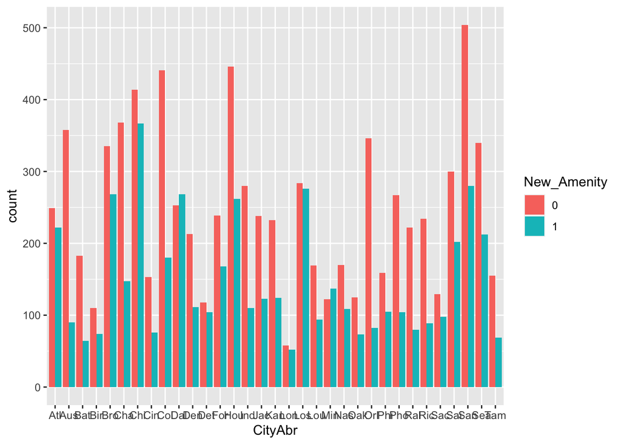

```r
ggplot(dataframe_cleaned, aes(x = CityAbr,fill = New_Amenity)) + geom_bar(position = "dodge")
```

The provided visualization suggests that the proportion of absent amenities across cities is higher than the proportion of present amenities, but it also shows that there is now a more balanced distribution between the two categories of the target variable.

Distribution of Amenity categories across different cities.

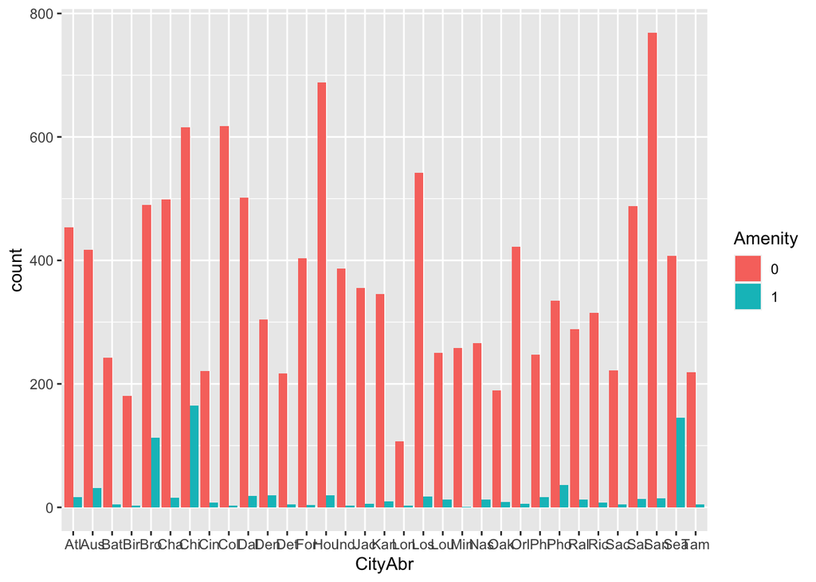

```r
ggplot(dataframe_cleaned, aes(x = CityAbr,fill = Amenity)) + geom_bar(position = "dodge")
```

The provided visualization suggests that the proportion of absent amenities across cities is significantly higher than the proportion of present amenities, indicating an imbalance between the two classes of the target variable.

Bar Plot representing the frequency of each unique category of Amenity

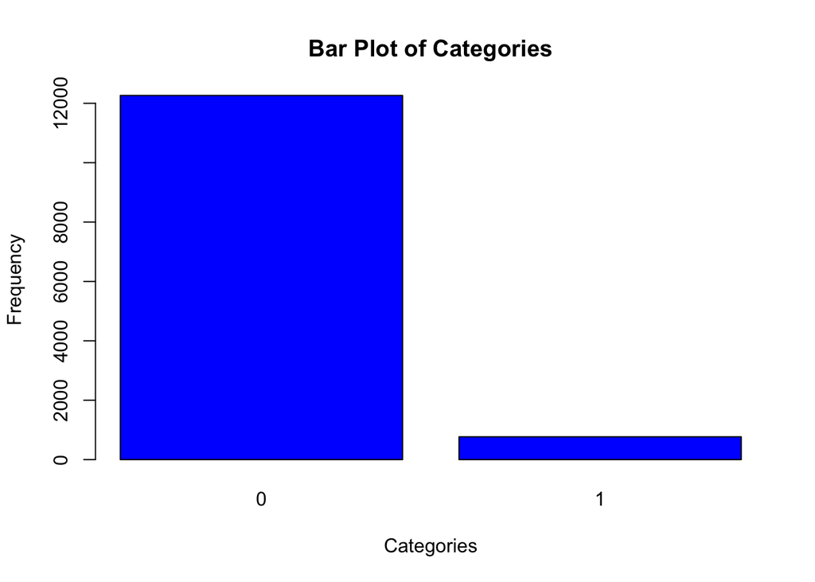

```r
category_counts <- table(dataframe_cleaned$Amenity)
barplot(category_counts,
        main = "Bar Plot of Categories",
        xlab = "Categories",
        ylab = "Frequency",
        col = "blue")
```

Ratio = Count of “no amenity” / Count of “presence of amenity” = 12,232 / 769 ≈ 15.89 The ratio in this context represents the class imbalance between the two categories of the target variable, where “no amenity” is significantly more common (approximately 15.89 times) than “presence of amenity.” This means that the dataset is skewed towards the “no amenity” category, and it’s imbalanced in favor of the majority class (“no amenity”).

Bar Plot representing the frequency of each unique category of New_Amenity

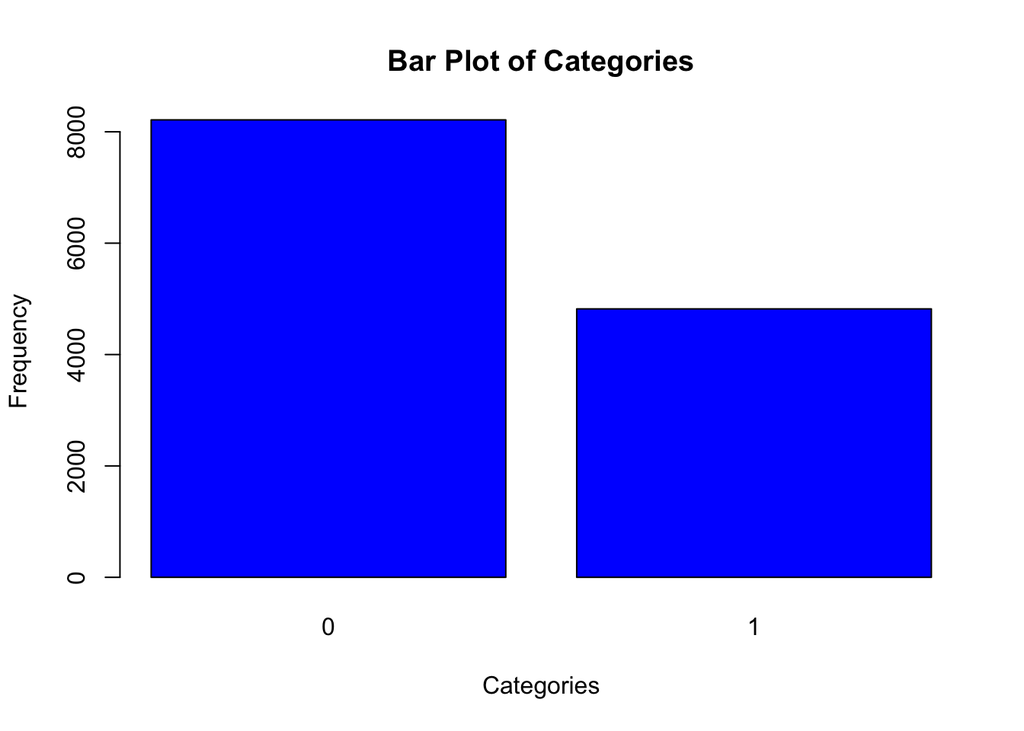

```r
category_counts <- table(dataframe_cleaned$New_Amenity)
barplot(category_counts,
        main = "Bar Plot of Categories",
        xlab = "Categories",
        ylab = "Frequency",
        col = "blue")
```

Ratio = Count of “no amenity” / Count of “presence of amenity” = 8,199 / 4,802 ≈ 1.71 The ratio in this context represents the class imbalance between the two categories of the target variable, where “no amenity” is approximately 1.71 times more common than “presence of amenity.” A ratio of 1.71 suggests that there is some imbalance in the dataset, but it’s not as severe as in case with the older amenity.

Grouped bar chart where the x-axis represents different Response time values, and for each Response time value, there are bars representing different categories of Amenity

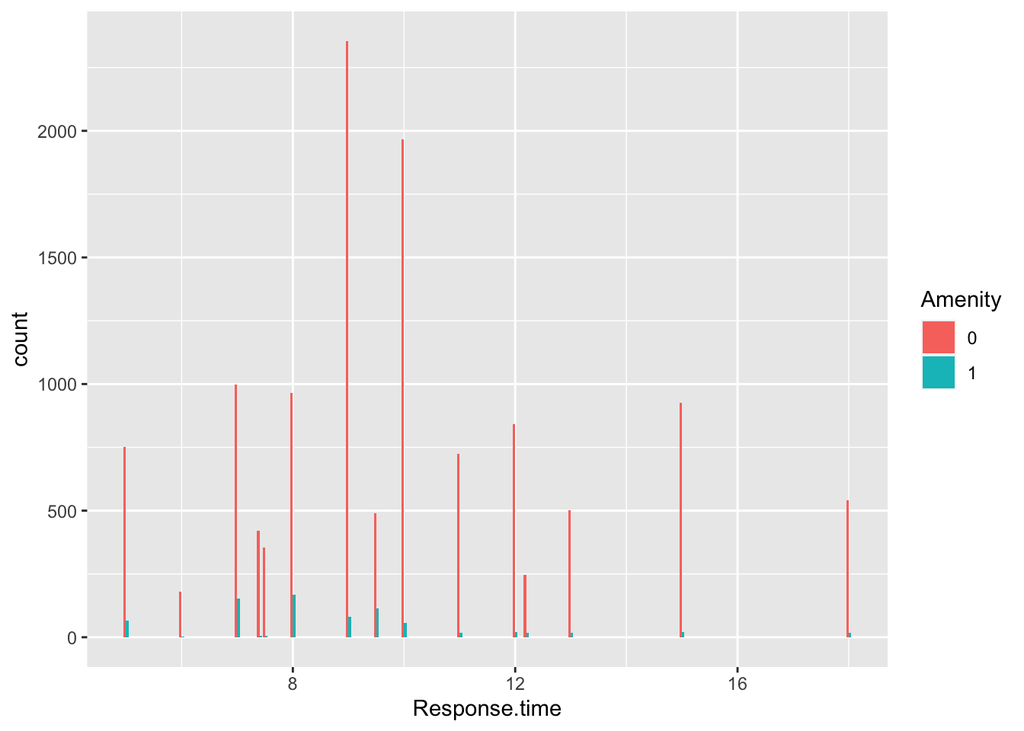

```r
ggplot(dataframe_cleaned, aes(x = `Response.time`,fill = Amenity)) + geom_bar(position = "dodge")
```

It appears that the Amenity category “0” has a higher frequency across most of the response time intervals compared to the category “1”, which has a much lower frequency.The distribution of the response times for Amenity “0” seems to be right-skewed, meaning there are a number of outliers with higher response times. Meanwhile, the distribution for Amenity “1” is less clear due to the lower counts but follows a similar pattern.

Grouped bar chart where the x-axis represents different Response time values, and for each Response time value, there are bars representing different categories of New_Amenity

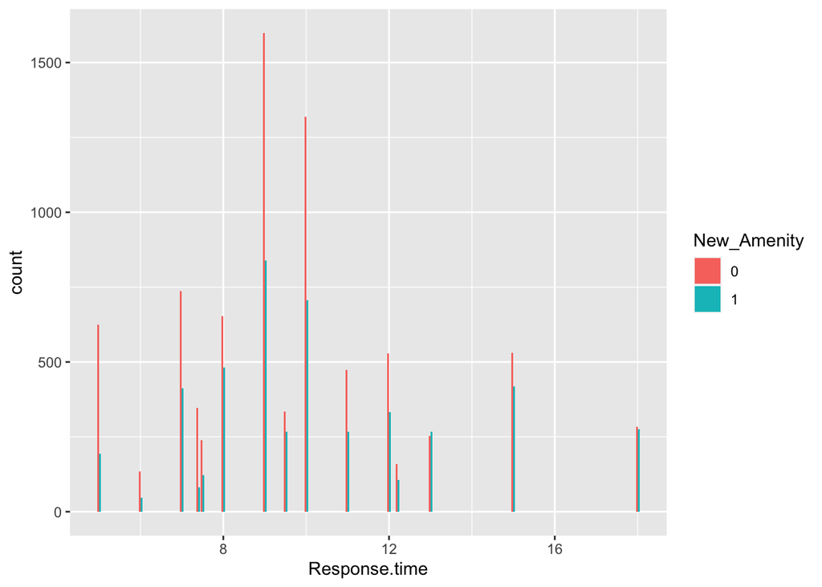

```r
ggplot(dataframe_cleaned, aes(x = `Response.time`,fill = New_Amenity)) + geom_bar(position = "dodge")
```

Category “0” still has a higher frequency across most response time bins compared to category “1”. Both categories show a right-skewed distribution, with the majority of the data points falling on the left side of the graph, indicating that lower response times are more frequent for both amenities. The distribution of the response times for the New_Amenity “0” has some prominent peaks, suggesting that there are specific response time intervals that are particularly common for this category. The distribution for the New_Amenity “1” appears more even across different response times but with significantly fewer counts than the category “0”.

Scaling or normalizing the data in order to make the data more interpretable.

```r
dataframe_cleaned$Sevprop_mod <- dataframe_cleaned$SeverityProportion * 1000000
dataframe_cleaned$Weights_mod <- dataframe_cleaned$Weights * 10000
unique_values1 <- unique(dataframe_cleaned$Sevprop_mod)
unique_values2 <- unique(dataframe_cleaned$Weights_mod)
```

Boxplot representing the distribution and summary statistics of the Severity Proportion.

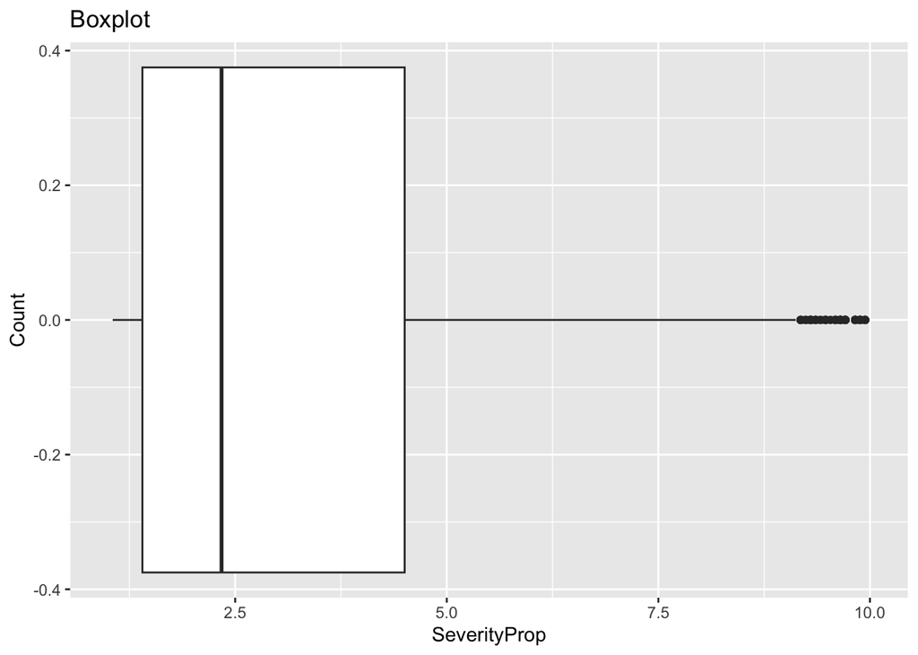

```r
ggplot(dataframe_cleaned, aes(x = Sevprop_mod)) +
     geom_boxplot() +
  labs(title = "Boxplot",
       x = "SeverityProp",
        y = "Count")+scale_x_continuous(limits = c(1, 10))
```

Boxplot representing the distribution and summary statistics of Weight.

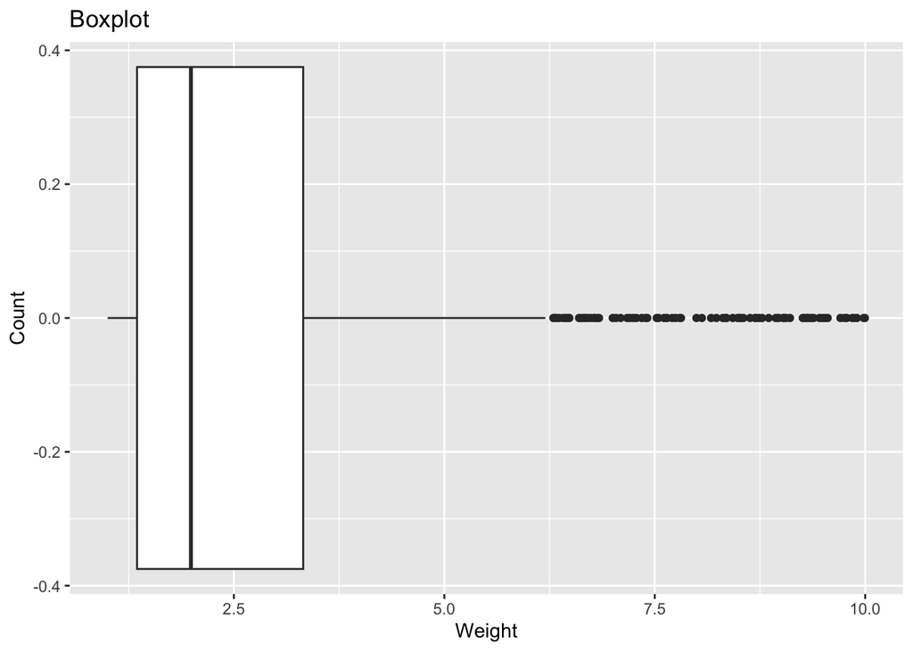

```r
ggplot(dataframe_cleaned, aes(x = Weights_mod)) +
     geom_boxplot() +
  labs(title = "Boxplot",
       x = "Weight",
        y = "Count")+scale_x_continuous(limits = c(1, 10))
```

The data is highly concentrated around a central value, with a significant number of outliers on the higher end. This suggests that most of the data points have lower ‘Weight’ values, with occasional higher values.

Scatter Plot of Severity Proportion vs. Weight” For Older Amenity where there are no Amenities

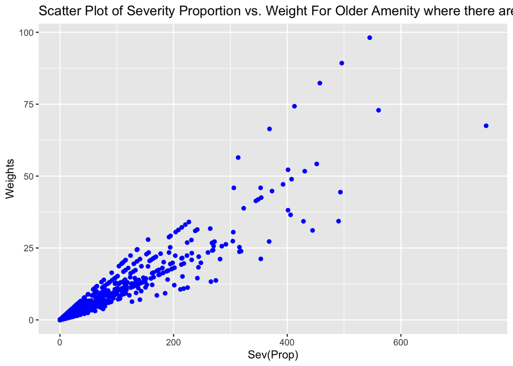

```r
df_sub <- subset(dataframe_cleaned,dataframe_cleaned$Amenity==0)
ggplot(df_sub, aes(x = Sevprop_mod, y = Weights_mod)) +
    geom_point(color = "blue") +  # Add points
    ggtitle("Scatter Plot of Severity Proportion vs. Weight For Older Amenity where there are no Amenities") +
    xlab("Sev(Prop)") +
    ylab("Weights")
```

There is a dense clustering of points toward the bottom left of the plot. This suggests that for lower values of “Sev(Prop)”, the weighted values is low.As “Severity Proportion” increases, the data points become more spread out, and the weighted values appears to increase for some cities, with a few reaching very high weighted values.The spread of points seems to widen with increasing “Sev(Prop)”, indicating more variability in weighted values at higher levels of “Severity Proportion”.

Scatter Plot of Severity Proportion vs. Weight For New Amenity where there are no Amenities

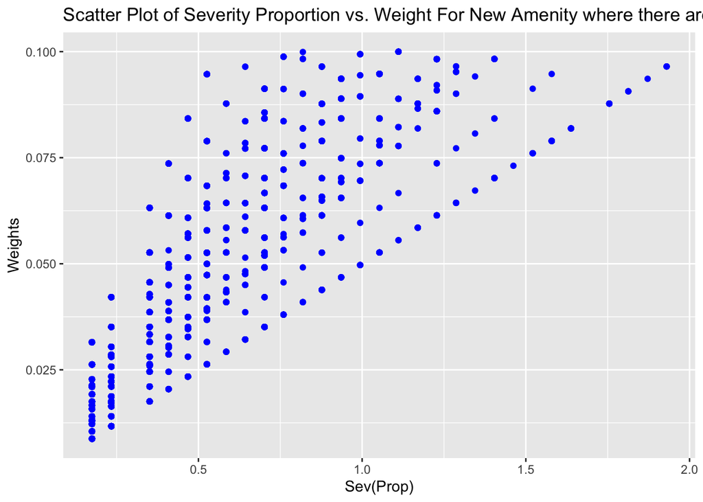

```r
df_sub <- subset(dataframe_cleaned,dataframe_cleaned$New_Amenity==0)
ggplot(df_sub, aes(x = Sevprop_mod, y = Weights_mod)) +
    geom_point(color = "blue") +  # Add points
    ggtitle("Scatter Plot of Severity Proportion vs. Weight For New Amenity where there are no Amenities") +
    xlab("Sev(Prop)") +
    ylab("Weights")
```

Scatter Plot of Severity Proportion vs. Weight For Older Amenity where there are Amenities

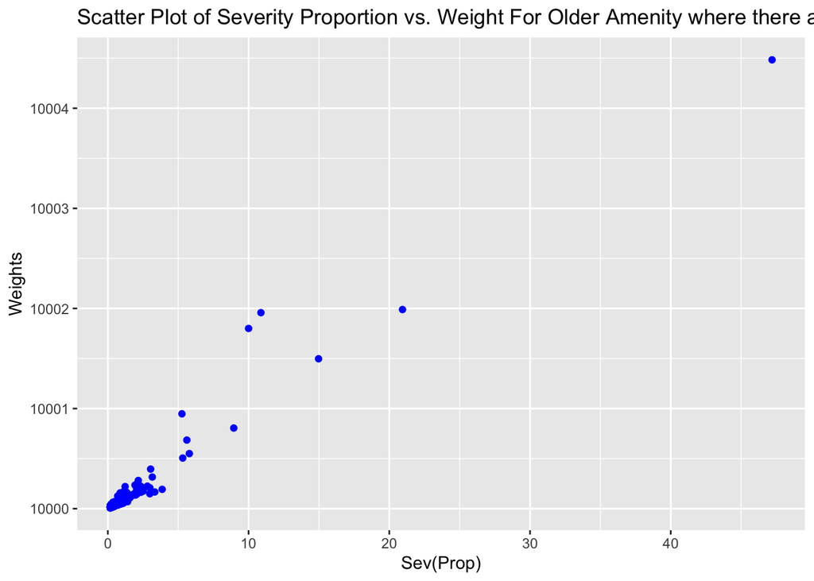

```r
df_subnew <- subset(dataframe_cleaned,dataframe_cleaned$Amenity==1)
ggplot(df_subnew, aes(x = Sevprop_mod, y = Weights_mod)) +
    geom_point(color = "blue") +  # Add points
    ggtitle("Scatter Plot of Severity Proportion vs. Weight For Older Amenity where there are Amenities") +
    xlab("Sev(Prop)") + ylab("Weights")
```

Scatter Plot of Severity Proportion vs. Weight For New Amenity where there are Amenities

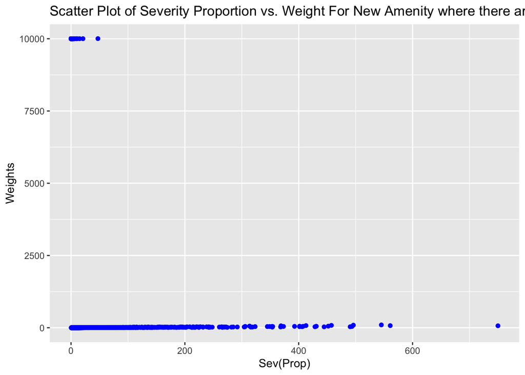

```r
df_subnew <- subset(dataframe_cleaned,dataframe_cleaned$New_Amenity==1)
ggplot(df_subnew, aes(x = Sevprop_mod, y = Weights_mod)) +
    geom_point(color = "blue") +
    ggtitle("Scatter Plot of Severity Proportion vs. Weight For New Amenity where there are Amenities") +
    xlab("Sev(Prop)") +
    ylab("Weights")
```

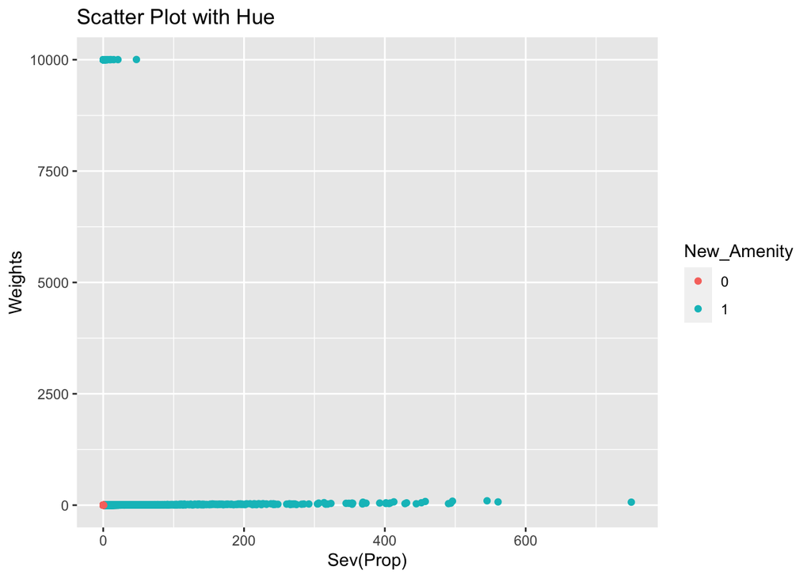

```r
ggplot(dataframe_cleaned, aes(x = Sevprop_mod, y = Weights_mod,color = New_Amenity)) +
    geom_point() +
    ggtitle("Scatter Plot with Hue") +
    xlab("Sev(Prop)") +
    ylab("Weights")
```

There is a significant clustering of blue points at the lower end of both axes, suggesting that for most observations, both Severity Proportion and Weights have low values.A few blue points are distributed sporadically at higher Weights values, indicating some variability for the “1” category of “New_Amenity”(i.e Indicating the data points with higher weights require the presence of amenities).The red points are few and are located at the lowest Severity Proportion and Weights values, suggesting that the “0” category of “New_Amenity” is associated with low Severity Proportion values.

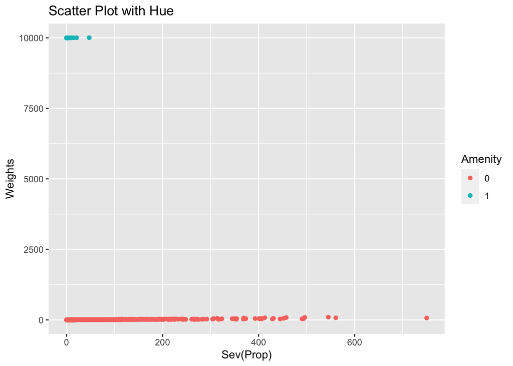

```r
ggplot(dataframe_cleaned, aes(x = Sevprop_mod, y = Weights_mod,color = Amenity)) +
    geom_point() +
    ggtitle("Scatter Plot with Hue") +
    xlab("Sev(Prop)") +
    ylab("Weights")
```

There is a notable concentration of red points along the baseline of the plot, indicating a high number of observations with the lowest Weights value across all Severity Proportion values(Indicating absence of amenities for most of the data points).Blue points occur less frequently and are mostly found at lower Severity Proportion values, except for a few instances where they appear at higher “Weights”(Indicating the data points with higher weights require the presence of amenities.)

# Modelling

```r
set.seed(123)
```

#### Train-Test Split Explanation

The provided R code performs a train-test split on a dataframe (`df`). This is a common practice in machine learning to assess the performance of a model on unseen data.

```r
indices <- sample(1:nrow(df), size = 0.72 * nrow(df))

# Create train and test datasets
train_data <- df[indices, ]
test_data <- df[-indices, ]
```

```r
train_data <- train_data[, !(colnames(train_data) %in% c('City', 'Street'))]
model_formula <- New.Amenity ~ .
model <- glm(model_formula, train_data, family = "binomial")
summary(model)
```

```
##
## Call:
## glm(formula = model_formula, family = "binomial", data = train_data)
##
## Deviance Residuals:
##    Min      1Q  Median      3Q     Max
##  -8.49    0.00    0.00    0.00    8.49
##
## Coefficients: (1 not defined because of singularities)
##                          Estimate Std. Error z value Pr(>|z|)
## (Intercept)            -1.067e+08  2.195e+04   -4860   <2e-16 ***
## SeverityProportion      4.644e+12  9.766e+08    4755   <2e-16 ***
## Amenity                -9.753e+12  2.014e+09   -4842   <2e-16 ***
## Response.time           4.457e+05  9.335e+01    4774   <2e-16 ***
## Weights                 9.753e+12  2.014e+09    4842   <2e-16 ***
## Weighted_Response_Time         NA         NA      NA       NA
## ---
## Signif. codes:  0 '***' 0.001 '**' 0.01 '*' 0.05 '.' 0.1 ' ' 1
##
## (Dispersion parameter for binomial family taken to be 1)
##
##     Null deviance: 12360.8  on 9383  degrees of freedom
## Residual deviance:  1946.4  on 9379  degrees of freedom
## AIC: 1956.4
##
## Number of Fisher Scoring iterations: 25
```

```r
test_data <- test_data[, !(colnames(test_data) %in% c('City', 'Street'))]
head(test_data,5)
```

```
##    SeverityProportion Amenity Response.time    Weights New.Amenity
## 3            2.34e-07       0            12 2.8080e-06           0
## 4            8.77e-07       0            12 1.0524e-05           1
## 8            2.34e-07       0            12 2.8080e-06           0
## 9            2.34e-07       0            12 2.8080e-06           0
## 19           2.34e-07       0            12 2.8080e-06           0
##    Weighted_Response_Time
## 3              2.8080e-06
## 4              1.0524e-05
## 8              2.8080e-06
## 9              2.8080e-06
## 19             2.8080e-06
```

```r
predicted_probs <- predict(model, newdata = test_data, type = "response")
predicted_labels <- ifelse(predicted_probs > 0.0001, 1, 0)

# Confusion Matrix and Accuracy
conf_matrix <- table(test_data$New.Amenity, predicted_labels)
accuracy <- sum(diag(conf_matrix))/sum(conf_matrix)
print(paste("Accuracy:", accuracy))
```

```
## [1] "Accuracy: 0.998904109589041"
```

- **Predicting Probabilities:** The predict function is used to obtain predicted probabilities from the trained model (model) on the test dataset (test_data).
- **Converting Probabilities to Binary Labels:** The predicted probabilities are then converted into binary labels using a threshold of 0.0001. If the predicted probability is greater than 0.0001, the label is set to 1; otherwise, it is set to 0.
- **Creating Confusion Matrix:** A confusion matrix (conf_matrix) is created by comparing the predicted binary labels with the true labels from the test dataset (test_data$New_Amenity).
- **Calculating Accuracy:** The accuracy of the model is calculated by summing the diagonal elements (correct predictions) of the confusion matrix and dividing it by the total number of predictions.

The accuracy is calculated as the sum of correct predictions (diagonal elements of the confusion matrix) divided by the total number of predictions. If the accuracy is printed as “1,” it suggests that all predictions made by the model on the test dataset were correct. This could be due to a few reasons:

**Perfect Model:** The model might be performing exceptionally well on the given dataset, correctly classifying all instances.

**Overfitting:** The model could be overfitting the training data, memorizing the patterns and not generalizing well to new, unseen data.

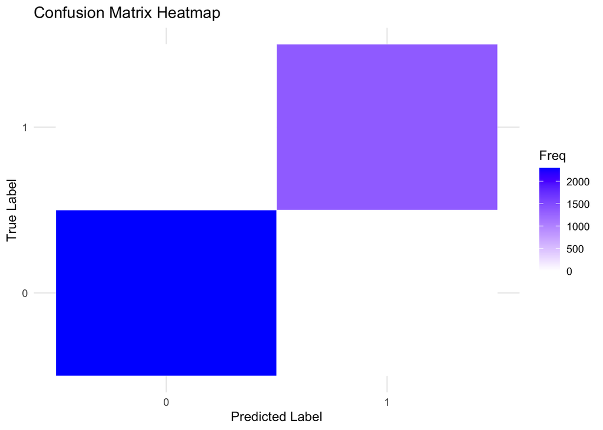

```r
conf_matrix_df <- as.data.frame(as.table(conf_matrix))
ggplot(conf_matrix_df, aes(x = Var1, y = predicted_labels, fill = Freq)) +
  geom_tile(color = "white") +
  scale_fill_gradient(low = "white", high = "blue") +
  theme_minimal() +
  labs(title = "Confusion Matrix Heatmap",
       x = "Predicted Label",
       y = "True Label")
```

#### Analysis of Confusion Matrix:

- 2323 instances were correctly predicted as class 0 (true negatives).
- 1323 instances were correctly predicted as class 1 (true positives).
- There were 4 instances where the actual class was 0 but were predicted as class 1 (false positives).
- There were no instances where the actual class was 1 but were predicted as class 0 (false negatives).

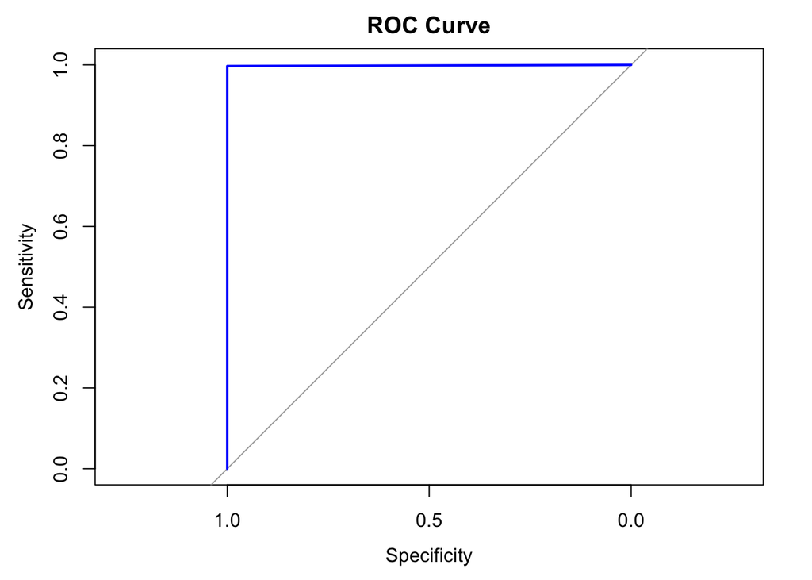

```r
roc_curve <- roc(test_data$New.Amenity, predicted_probs)
plot(roc_curve, main = "ROC Curve", col = "blue", lwd = 2)
```

```r
head(train_data)
```

```
##       SeverityProportion Amenity Response.time     Weights New.Amenity
## 2463          4.0900e-07       0            11 0.000004499           0
## 2511          3.5100e-07       0             8 0.000002808           0
## 10419         3.6554e-05       0            10 0.000365540           1
## 8718          3.5100e-07       0            15 0.000005265           0
## 12483         2.3400e-07       0             7 0.000001638           0
## 2986          1.3627e-05       0             8 0.000109016           1
##       Weighted_Response_Time
## 2463             0.000004499
## 2511             0.000002808
## 10419            0.000365540
## 8718             0.000005265
## 12483            0.000001638
## 2986             0.000109016
```

```r
train_data$New.Amenity <- factor(train_data$New.Amenity, levels = c(0, 1))
knn_model <- train(New.Amenity ~ ., data = train_data, method = "knn")
```

```r
summary(knn_model)
```

```
##             Length Class      Mode
## learn       2      -none-     list
## k           1      -none-     numeric
## theDots     0      -none-     list
## xNames      5      -none-     character
## problemType 1      -none-     character
## tuneValue   1      data.frame list
## obsLevels   2      -none-     character
## param       0      -none-     list
```

#### **Sensitivity and Specificity:**

**Specificity (True Negative Rate): 99.55%** The proportion of actual negative instances that were correctly predicted.

#### **Positive Predictive Value (Precision) and Negative Predictive Value:**

**Pos Pred Value (Precision): 99.74%** The proportion of instances predicted as positive that are truly positive.

#### **Conclusion:**

- The model shows very high accuracy, sensitivity, specificity, and precision.
- The Kappa statistic suggests excellent agreement beyond what would be expected by chance.
- The model performs significantly better than predicting the majority class in terms of accuracy.
- It’s important to consider the specific context and requirements of the problem to determine if this level of performance is satisfactory.

```r
# Check levels in test data
levels(test_data$New.Amenity)
```

[output not shown]

```r
levels(train_data$New.Amenity)
```

```
## [1] "0" "1"
```

```r
test_data$New.Amenity <- factor(test_data$New.Amenity, levels = c(0, 1))
predictions <- predict(knn_model, newdata = test_data)
```

```r
head(test_data)
```

```
##    SeverityProportion Amenity Response.time    Weights New.Amenity
## 3            2.34e-07       0            12 2.8080e-06           0
## 4            8.77e-07       0            12 1.0524e-05           1
## 8            2.34e-07       0            12 2.8080e-06           0
## 9            2.34e-07       0            12 2.8080e-06           0
## 19           2.34e-07       0            12 2.8080e-06           0
## 22           4.68e-07       0            12 5.6160e-06           0
##    Weighted_Response_Time
## 3              2.8080e-06
## 4              1.0524e-05
## 8              2.8080e-06
## 9              2.8080e-06
## 19             2.8080e-06
## 22             5.6160e-06
```

```r
# Confusion Matrix and Accuracy
conf_matrix <- confusionMatrix(predictions, test_data$New.Amenity)
print(conf_matrix)
```

```
## Confusion Matrix and Statistics
##
##           Reference
## Prediction    0    1
##          0 2294    6
##          1    2 1348
##
##                Accuracy : 0.9978
##                  95% CI : (0.9957, 0.9991)
##     No Information Rate : 0.629
##     P-Value [Acc > NIR] : <2e-16
##
##                   Kappa : 0.9953
##
##  Mcnemar's Test P-Value : 0.2888
##
##             Sensitivity : 0.9991
##             Specificity : 0.9956
##          Pos Pred Value : 0.9974
##          Neg Pred Value : 0.9985
##              Prevalence : 0.6290
##          Detection Rate : 0.6285
##    Detection Prevalence : 0.6301
##       Balanced Accuracy : 0.9973
##
##        'Positive' Class : 0
##
```

```r
length(predictions)
```

```
## [1] 3650
```

```r
length(test_data$New.Amenity)
```

```
## [1] 3650
```

###### Predicting the Severity

```r
accidents_data <- read.csv('/Users/apoorvareddy/Downloads/Academic/DATS6101/Project/US_accidents_EDA.csv')

# Data Preprocessing
# Check for missing values
sum(is.na(accidents_data))
```

```
## [1] 0
```

```r
accidents_data$Weather_Condition <- as.factor(accidents_data$Weather_Condition)
accidents_data$Wind_Direction <- as.factor(accidents_data$Wind_Direction)
accidents_data$Sunrise_Sunset <- as.factor(accidents_data$Sunrise_Sunset)

# Create a binary variable indicating high or low severity (you can define a threshold)
accidents_data$HighSeverity <- ifelse(accidents_data$Severity > 2, 1, 0)
# Split the dataset into training and testing sets
set.seed(123)
split_index <- sample(nrow(accidents_data), size = 4000)
train_data <- accidents_data[split_index, ]
test_data <- accidents_data[-split_index, ]

# Select relevant features based on your domain knowledge
selected_features <- c('Temperature.F.', 'Humidity...', 'Pressure.in.', 'Visibility.mi.', 'Wind_Direction')


# Train a predictive model (using logistic regression in this case)
model <- glm(HighSeverity ~ ., data = train_data[, c('HighSeverity', selected_features)], family = "binomial")

# Make predictions on the test set
predictions <- predict(model, newdata = test_data[, selected_features], type = "response")

# Convert probabilities to binary predictions
binary_predictions <- ifelse(predictions > 0.5, 1, 0)

# Convert actual outcomes to factor with the same levels as binary_predictions
test_data$HighSeverity <- as.factor(test_data$HighSeverity)
binary_predictions <- as.factor(binary_predictions)
# Evaluate the model
confusion_matrix <- confusionMatrix(binary_predictions, test_data$HighSeverity)
print(confusion_matrix)
```

```
## Confusion Matrix and Statistics
##
##           Reference
## Prediction       0       1
##          0 5733178 1314168
##          1     123      87
##
##                Accuracy : 0.8135
##                  95% CI : (0.8132, 0.8138)
##     No Information Rate : 0.8135
##     P-Value [Acc > NIR] : 0.5141
##
##                   Kappa : 1e-04
##
##  Mcnemar's Test P-Value : <2e-16
##
##             Sensitivity : 0.9999785
##             Specificity : 0.0000662
##          Pos Pred Value : 0.8135230
##          Neg Pred Value : 0.4142857
##              Prevalence : 0.8135162
##          Detection Rate : 0.8134988
##    Detection Prevalence : 0.9999702
##       Balanced Accuracy : 0.5000224
##
##        'Positive' Class : 0
##
```

In the data preprocessing stage, missing values were checked and categorical variables were converted into factors. A binary variable, HighSeverity, denoting accidents with severity greater than 2, was created. The dataset was then split into training and testing sets, and relevant features such as temperature, humidity, pressure, visibility, and wind direction were selected based on domain knowledge. A logistic regression model was trained using these features, and predictions on the test set were made, with probabilities converted to binary outcomes using a 0.5 threshold. The model’s performance evaluation revealed an accuracy of 81.35%, with a 95% confidence interval between 81.32% and 81.38%. Comparison to the No Information Rate yielded a p-value of 0.5141, indicating no significant difference. The Kappa statistic was minimal at 1e-04, suggesting limited agreement beyond chance. Mcnemar’s test, however, indicated a significant difference in performance between predicted and actual outcomes with a highly significant p-value of <2e-16.

# Conclusion